# Introduction to Linux/HPC

Research Informatics Core

June 25, 2025

# 1 Morning

## 1.1 Login to lakeshore

###### 1.1.0.0.0.1 For Windows Users

1. Open *PuTTY*
2. Enter `lakeshore.acer.uic.edu` as HostName

[figure not shown]

3. Click **Open**
4. Enter your netID at the “login as:” prompt

###### 1.1.0.0.0.2 For macOS/Linux Users

1. Open Terminal appliation
2. Execute the following

```bash
ssh <netID>@lakeshore.acer.uic.edu
```

### 1.1.1 Public Key Authentication

###### 1.1.1.0.0.1 For Windows Users

1. Enter login username in Connection->Data

[figure not shown]

2. Click Browse in Connection->SSH->Auth and load your key.

[figure not shown]

## 1.2 Simple Commands

- Print the system date

```bash
date
```

```
Mon Jun 23 02:36:23 PM CDT 2025
```

- Prints the username of the person executing the command ‘whoami’

```bash
whoami
```

```
mmaiensc
```

- Prints the group membership of the person executing the command ‘groups’

```bash
groups
```

```
mmaiensc ric_workshop
```

- Print the Working Directory.

```bash
pwd
```

```
/home/mmaiensc
```

- Prints the hostname of the server. Typically also found with shell prompt

```bash
hostname
```

```
lakeshore.acer.uic.edu
```

## 1.3 List (`ls`), change directory (`cd`), and print working directory (`pwd`) commands

### 1.3.1 List the content (subdirectories and/or files) within the directory

- List all the files and sub-directories in the current directory

```bash
ls
```

```
compile.sh
compile.sh.o104701
cyberduck01.png
Introduction_to_Linux.Rmd
linux_exercise_1.1a.png
linux_exercise_1.1b.png
linux_exercise_1.png
nano.png
pageant_icon.png
puttygen01.png
puttygen03.png
puttygen04.png
puttygen_icon.png
putty_icon.png
putty-sshkey.png
winscp01.png
```

- List all files/sub-directories
- `-l` Output one entry per line, with file size and permissions
- `-h` Show file size in human readable format

```bash
ls -lh
```

```
total 11M
-rw-rw-r-- 1 gchlip2 gchlip2  844 Jun 23 14:36 compile.sh
-rw-rw-r-- 1 gchlip2 gchlip2 3.0K Jun 23 14:36 compile.sh.o104701
-rw-rw-r-- 1 gchlip2 gchlip2 121K Jun  5 11:30 cyberduck01.png
-rw-rw-r-- 1 gchlip2 gchlip2  33K Jun 23 14:35 Introduction_to_Linux.Rmd
-rwxrwxr-x 1 gchlip2 gchlip2  63K Jun  5 11:30 linux_exercise_1.1a.png
-rwxrwxr-x 1 gchlip2 gchlip2  77K Jun  5 11:30 linux_exercise_1.1b.png
-rw-rw-r-- 1 gchlip2 gchlip2 123K Jun  5 11:30 linux_exercise_1.png
-rwxrwxr-x 1 gchlip2 gchlip2 521K Jun  5 11:30 nano.png
-rw-rw-r-- 1 gchlip2 gchlip2  469 Jun  5 11:30 pageant_icon.png
-rw-rw-r-- 1 gchlip2 gchlip2  72K Jun  5 11:30 puttygen01.png
-rw-rw-r-- 1 gchlip2 gchlip2 181K Jun  5 11:30 puttygen03.png
-rw-rw-r-- 1 gchlip2 gchlip2 185K Jun  5 11:30 puttygen04.png
-rw-rw-r-- 1 gchlip2 gchlip2  611 Jun  5 11:30 puttygen_icon.png
-rw-rw-r-- 1 gchlip2 gchlip2  580 Jun  5 11:30 putty_icon.png
-rw-rw-r-- 1 gchlip2 gchlip2 133K Jun  5 11:30 putty-sshkey.png
-rw-rw-r-- 1 gchlip2 gchlip2  47K Jun  5 11:30 winscp01.png
```

- List everything in `/workshops/ric_workshop/common/2_LinuxHPC` Note this directory does not have to be current directory

```bash
ls -lh /workshops/ric_workshop/common/2_LinuxHPC
```

```
total 136M
drwxr-xr-x. 2 pkanabar rrc_shared 512 May 29 13:53 files
-rw-r--r--. 1 pkanabar rrc_shared 68M May 29 13:53 hg19_chr19_annotation.gtf
-rw-r--r--. 1 pkanabar rrc_shared 68M Jun 20 02:30 hg19_chr19.gtf
-rw-r--r--  1 pkanabar rrc_shared 796 Jun 20 11:44 SLURM_template.sh
```

- List everything in `/workshops/ric_workshop/common/2_LinuxHPC` ending with *.gtf.

```bash
ls -lh /workshops/ric_workshop/common/2_LinuxHPC/*.gtf
```

```
-rw-r--r--. 1 pkanabar rrc_shared 68M May 29 13:53 /workshops/ric_workshop/common/2_LinuxHPC/hg19_chr19_annotation.gtf
-rw-r--r--. 1 pkanabar rrc_shared 68M Jun 20 02:30 /workshops/ric_workshop/common/2_LinuxHPC/hg19_chr19.gtf
```

- List what is in your home directory

```bash
ls ~
```

```
compile.sh
compile.sh.o104701
cyberduck01.png
Introduction_to_Linux.Rmd
linux_exercise_1.1a.png
linux_exercise_1.1b.png
linux_exercise_1.png
nano.png
pageant_icon.png
puttygen01.png
puttygen03.png
puttygen04.png
puttygen_icon.png
putty_icon.png
putty-sshkey.png
winscp01.png
```

- Show all the different option for command `ls`. Always use `man` command to get information on additional options and explanation

```bash
man ls
```

### 1.3.2 Explore `cd` and `pwd` Commands

- Change (current) directory; go to home directory.

```bash
cd
```

- Print the working (current) directory

```bash
pwd
```

- This will take you to the `2_LinuxHPC` directory using absolute path.

```bash
cd /workshops/ric_workshop/common/2_LinuxHPC
pwd
```

- This will take you one level above (i.e. to `common`)

```bash
cd ./../
pwd
```

- This will take you two level above from our current directory

```bash
cd ./../../
pwd
```

- Go back to the last working directory

```bash
cd -
pwd
```

## 1.4 Working with files and directories

### 1.4.1 Create, Rename, and Delete directory

- Create a directory under your home directory

```bash
mkdir ~/workingdir
```

- Create a sub directory called newdir

```bash
mkdir /home/<netid>/workingdir/newdir
```

```bash
cd workingdir
mv newdir myfirstsubdir
rm myfirstsubdir
```

```
rm: cannot remove 'myfirstsubdir': Is a directory
```

Command will fail, as we need `-r` (recursive) for directories

```bash
rm -r myfirstsubdir
```

Remove directory called ‘`myfirstdir`’. This will remove all the subdirectories and files in ‘`myfirstdir`’.

### 1.4.2 Working with files: Create, copy, move, and delete a file

- Go to `workingdir` directory

```bash
cd ~/workingdir
```

- Create an empty file

```bash
touch myfirstfile.txt
```

- Make a copy of file ‘`myfirstfile.txt`’ and name it `2.txt`. Both the files are in the same directory.

```bash
cp myfirstfile.txt 2.txt
```

- Move `2.txt` file to my home directory and rename it to `two.txt`. Note:The `mv`command can also rename a file while moving it to a different location!

```bash
mv 2.txt ~/two.txt
```

- List the directory to see the results

```bash
ls
```

```
myfirstfile.txt
myfirstsubdir
```

- List your home directory

```bash
ls ~
```

```
compile.sh
compile.sh.o104701
cyberduck01.png
Introduction_to_Linux.Rmd
linux_exercise_1.1a.png
linux_exercise_1.1b.png
linux_exercise_1.png
nano.png
pageant_icon.png
puttygen01.png
puttygen03.png
puttygen04.png
puttygen_icon.png
putty_icon.png
putty-sshkey.png
two.txt
winscp01.png
workingdir
```

- Remove `two.txt` file from my home directory (NO TRASHBIN)

```bash
rm ~/two.txt
```

- List your home directory to see the results

```bash
ls ~
```

```
compile.sh
compile.sh.o104701
cyberduck01.png
Introduction_to_Linux.Rmd
linux_exercise_1.1a.png
linux_exercise_1.1b.png
linux_exercise_1.png
nano.png
pageant_icon.png
puttygen01.png
puttygen03.png
puttygen04.png
puttygen_icon.png
putty_icon.png
putty-sshkey.png
winscp01.png
workingdir
```

## 1.5 Permissions and links

- List files in directory to view permissions.

```bash
ls -l
```

```
total 11009
-rw-rw-r-- 1 gchlip2 gchlip2    844 Jun 23 14:36 compile.sh
-rw-rw-r-- 1 gchlip2 gchlip2   5265 Jun 23 14:37 compile.sh.o104701
-rw-rw-r-- 1 gchlip2 gchlip2 123165 Jun  5 11:30 cyberduck01.png
-rw-rw-r-- 1 gchlip2 gchlip2  33684 Jun 23 14:35 Introduction_to_Linux.Rmd
-rwxrwxr-x 1 gchlip2 gchlip2  63922 Jun  5 11:30 linux_exercise_1.1a.png
-rwxrwxr-x 1 gchlip2 gchlip2  78286 Jun  5 11:30 linux_exercise_1.1b.png
-rw-rw-r-- 1 gchlip2 gchlip2 125159 Jun  5 11:30 linux_exercise_1.png
-rwxrwxr-x 1 gchlip2 gchlip2 533443 Jun  5 11:30 nano.png
-rw-rw-r-- 1 gchlip2 gchlip2    469 Jun  5 11:30 pageant_icon.png
-rw-rw-r-- 1 gchlip2 gchlip2  72894 Jun  5 11:30 puttygen01.png
-rw-rw-r-- 1 gchlip2 gchlip2 184328 Jun  5 11:30 puttygen03.png
-rw-rw-r-- 1 gchlip2 gchlip2 188578 Jun  5 11:30 puttygen04.png
-rw-rw-r-- 1 gchlip2 gchlip2    611 Jun  5 11:30 puttygen_icon.png
-rw-rw-r-- 1 gchlip2 gchlip2    580 Jun  5 11:30 putty_icon.png
-rw-rw-r-- 1 gchlip2 gchlip2 135354 Jun  5 11:30 putty-sshkey.png
-rw-rw-r-- 1 gchlip2 gchlip2  47724 Jun  5 11:30 winscp01.png
drwxr-xr-x 3 gchlip2 gchlip2    512 Jun 23 14:37 workingdir
```

- Grant write permission to group on workingdir

```bash
chmod g+w workingdir
```

- Create symbolic link to common workshop directory

```bash
ln -s /workshops/ric_workshop/common/2_LinuxHPC workshop_dir
```

```bash
ls -l
```

```
total 11009
-rw-rw-r-- 1 gchlip2 gchlip2    844 Jun 23 14:36 compile.sh
-rw-rw-r-- 1 gchlip2 gchlip2   5550 Jun 23 14:37 compile.sh.o104701
-rw-rw-r-- 1 gchlip2 gchlip2 123165 Jun  5 11:30 cyberduck01.png
-rw-rw-r-- 1 gchlip2 gchlip2  33684 Jun 23 14:35 Introduction_to_Linux.Rmd
-rwxrwxr-x 1 gchlip2 gchlip2  63922 Jun  5 11:30 linux_exercise_1.1a.png
-rwxrwxr-x 1 gchlip2 gchlip2  78286 Jun  5 11:30 linux_exercise_1.1b.png
-rw-rw-r-- 1 gchlip2 gchlip2 125159 Jun  5 11:30 linux_exercise_1.png
-rwxrwxr-x 1 gchlip2 gchlip2 533443 Jun  5 11:30 nano.png
-rw-rw-r-- 1 gchlip2 gchlip2    469 Jun  5 11:30 pageant_icon.png
-rw-rw-r-- 1 gchlip2 gchlip2  72894 Jun  5 11:30 puttygen01.png
-rw-rw-r-- 1 gchlip2 gchlip2 184328 Jun  5 11:30 puttygen03.png
-rw-rw-r-- 1 gchlip2 gchlip2 188578 Jun  5 11:30 puttygen04.png
-rw-rw-r-- 1 gchlip2 gchlip2    611 Jun  5 11:30 puttygen_icon.png
-rw-rw-r-- 1 gchlip2 gchlip2    580 Jun  5 11:30 putty_icon.png
-rw-rw-r-- 1 gchlip2 gchlip2 135354 Jun  5 11:30 putty-sshkey.png
-rw-rw-r-- 1 gchlip2 gchlip2  47724 Jun  5 11:30 winscp01.png
drwxrwxr-x 3 gchlip2 gchlip2    512 Jun 23 14:37 workingdir
```

## 1.6 Viewing files, redirects, and pipes

### 1.6.1 Using, `cat`, `less`, and `more` commands to view the content of the gtf file

**Remember to use tab to autocomplete path names!!!**

To navigate the `less` and `more` commands, use: * Space bar to move down a page of text * Enter key to move down a single line of text * `q` to quit

```bash
cd ~/workingdir
cp /workshops/ric_workshop/common/2_LinuxHPC/hg19_chr19_annotation.gtf hg19_chr19.gtf
cat hg19_chr19.gtf
less hg19_chr19.gtf
more hg19_chr19.gtf
head hg19_chr19.gtf
```

```
##description: evidence-based annotation of the human genome (GRCh37), version 19 (Ensembl 74)
##provider: GENCODE
##contact: gencode@sanger.ac.uk
##format: gtf
chr19   HAVANA  gene    60105   71626   .   -   .   gene_id "ENSG00000225373.4"; transcript_id "ENSG00000225373.4"; gene_type "pseudogene"; gene_status "KNOWN"; gene_name "WASH5P"; transcript_type "pseudogene"; transcript_status "KNOWN"; transcript_name "WASH5P"; level 2; havana_gene "OTTHUMG0000018…
chr19   HAVANA  transcript  60105   70951   .   -   .   gene_id "ENSG00000225373.4"; transcript_id "ENST00000592209.2"; gene_type "pseudogene"; gene_status "KNOWN"; gene_name "WASH5P"; transcript_type "processed_transcript"; transcript_status "KNOWN"; transcript_name "WASH5P-002"; level 2; havana_ge…
chr19   HAVANA  exon    70928   70951   .   -   .   gene_id "ENSG00000225373.4"; transcript_id "ENST00000592209.2"; gene_type "pseudogene"; gene_status "KNOWN"; gene_name "WASH5P"; transcript_type "processed_transcript"; transcript_status "KNOWN"; transcript_name "WASH5P-002"; exon_number 1;  exon_i…
chr19   HAVANA  exon    66346   66499   .   -   .   gene_id "ENSG00000225373.4"; transcript_id "ENST00000592209.2"; gene_type "pseudogene"; gene_status "KNOWN"; gene_name "WASH5P"; transcript_type "processed_transcript"; transcript_status "KNOWN"; transcript_name "WASH5P-002"; exon_number 2;  exon_i…
chr19   HAVANA  exon    60521   60747   .   -   .   gene_id "ENSG00000225373.4"; transcript_id "ENST00000592209.2"; gene_type "pseudogene"; gene_status "KNOWN"; gene_name "WASH5P"; transcript_type "processed_transcript"; transcript_status "KNOWN"; transcript_name "WASH5P-002"; exon_number 3;  exon_i…
chr19   HAVANA  exon    60105   60162   .   -   .   gene_id "ENSG00000225373.4"; transcript_id "ENST00000592209.2"; gene_type "pseudogene"; gene_status "KNOWN"; gene_name "WASH5P"; transcript_type "processed_transcript"; transcript_status "KNOWN"; transcript_name "WASH5P-002"; exon_number 4;  exon_i…
```

```
##description: evidence-based annotation of the human genome (GRCh37), version 19 (Ensembl 74)
##provider: GENCODE
##contact: gencode@sanger.ac.uk
##format: gtf
chr19   HAVANA  gene    60105   71626   .   -   .   gene_id "ENSG00000225373.4"; transcript_id "ENSG00000225373.4"; gene_type "pseudogene"; gene_status "KNOWN"; gene_name "WASH5P"; transcript_type "pseudogene"; transcript_status "KNOWN"; transcript_name "WASH5P"; level 2; havana_gene "OTTHUMG0000018…
chr19   HAVANA  transcript  60105   70951   .   -   .   gene_id "ENSG00000225373.4"; transcript_id "ENST00000592209.2"; gene_type "pseudogene"; gene_status "KNOWN"; gene_name "WASH5P"; transcript_type "processed_transcript"; transcript_status "KNOWN"; transcript_name "WASH5P-002"; level 2; havana_ge…
chr19   HAVANA  exon    70928   70951   .   -   .   gene_id "ENSG00000225373.4"; transcript_id "ENST00000592209.2"; gene_type "pseudogene"; gene_status "KNOWN"; gene_name "WASH5P"; transcript_type "processed_transcript"; transcript_status "KNOWN"; transcript_name "WASH5P-002"; exon_number 1;  exon_i…
chr19   HAVANA  exon    66346   66499   .   -   .   gene_id "ENSG00000225373.4"; transcript_id "ENST00000592209.2"; gene_type "pseudogene"; gene_status "KNOWN"; gene_name "WASH5P"; transcript_type "processed_transcript"; transcript_status "KNOWN"; transcript_name "WASH5P-002"; exon_number 2;  exon_i…
chr19   HAVANA  exon    60521   60747   .   -   .   gene_id "ENSG00000225373.4"; transcript_id "ENST00000592209.2"; gene_type "pseudogene"; gene_status "KNOWN"; gene_name "WASH5P"; transcript_type "processed_transcript"; transcript_status "KNOWN"; transcript_name "WASH5P-002"; exon_number 3;  exon_i…
chr19   HAVANA  exon    60105   60162   .   -   .   gene_id "ENSG00000225373.4"; transcript_id "ENST00000592209.2"; gene_type "pseudogene"; gene_status "KNOWN"; gene_name "WASH5P"; transcript_type "processed_transcript"; transcript_status "KNOWN"; transcript_name "WASH5P-002"; exon_number 4;  exon_i…
```

### 1.6.2 Echo Command, Redirects and Pipes

- Go to `workingdir` directory

```bash
cd ~/workingdir
```

- `1>` redirects STDOUT (stream 1) to a new file called ‘`filename.txt`’.

```bash
echo "Today's Workshop Day is all about linux" 1> filename.txt
```

- `>>` appends to the same file

```bash
echo "We are learning about redirects" >> filename.txt
```

- `>>` append again

```bash
echo "This exercise is about understanding redirects" >> filename.txt
```

- ‘<’ reads file into STDIN

```bash
head -n 2 < filename.txt
```

```
Today's Workshop Day is all about linux
We are learning about redirects
```

```bash
cat filename.txt 1> t1.txt  ## (STDOUT)
wc -l t1.txt  ## count number lines in the t1.txt
```

```
3 t1.txt
```

- If `filename.txt` does not exist, error message is on STDERR (stream 2)

```bash
cat filename.txt 2> output.txt
cat output.txt
```

```
Today's Workshop Day is all about linux
We are learning about redirects
This exercise is about understanding redirects
```

- Let’s stich few commands together using ‘pipe’. Goal: Get top 10 lines from hg19_chr19.gtf, and then redirect last five line to temp.txt

```bash
head hg19_chr19.gtf | tail -n 5 > temp.txt
```

## 1.7 Filter utilities

Using cut, less/more, sort, and uniq commands to view the content of the gtf file

- Go to `workingdir` directory

```bash
cd ~/workingdir
```

- If you haven’t already done so, make a copy of the hg19_chr19.gtf file

```bash
cp /workshops/ric_workshop/common/2_LinuxHPC/hg19_chr19_annotation.gtf hg19_chr19.gtf
```

- Cut column 1 and 3 from hg19_chr19.gtf

```bash
cut -f 1,3 hg19_chr19.gtf
```

```
##description: evidence-based annotation of the human genome (GRCh37), version 19 (Ensembl 74)
##provider: GENCODE
##contact: gencode@sanger.ac.uk
##format: gtf
chr19   gene
chr19   transcript
chr19   exon
chr19   exon
chr19   exon
chr19   exon
```

- Cut column 1 and 3 from hg19_chr19.gtf, pipe to less to view page at a time

```bash
cut -f 1,3 hg19_chr19.gtf | less
```

- Cut column 3 from hg19_chr19.gtf, pipe to `sort`, pipe to `uniq` command to count number of uniq feature records and associated counts and sort again.

```bash
cut -f 3 hg19_chr19.gtf | sort | uniq -c
```

```
  44556 CDS
      1 ##contact: gencode@sanger.ac.uk
      1 ##description: evidence-based annotation of the human genome (GRCh37), version 19 (Ensembl 74)
  72639 exon
      1 ##format: gtf
   2910 gene
      1 ##provider: GENCODE
     16 Selenocysteine
   6375 start_codon
   5710 stop_codon
```

```bash
cut -f 3 hg19_chr19.gtf | sort | uniq -c | sort -g
```

```
      1 ##contact: gencode@sanger.ac.uk
      1 ##description: evidence-based annotation of the human genome (GRCh37), version 19 (Ensembl 74)
      1 ##format: gtf
      1 ##provider: GENCODE
     16 Selenocysteine
   2910 gene
   5710 stop_codon
   6375 start_codon
  12758 transcript
  20974 UTR
```

## 1.8 Filter utilities: `find`

General Syntax: find location comparison-criteria search-term

- Go to `workingdir` directory

```bash
cd ~/workingdir
```

- List everything in the current directory

```bash
find . -print
```

```
.
./myfirstsubdir
./filename.txt
./myfirstfile.txt
./t1.txt
./hg19_chr19.gtf
./output.txt
```

- Find all the file(s) ending with .gtf extension in workshop directory

```bash
find /workshops/ric_workshop -name "*.gtf" -print
```

```
/workshops/ric_workshop/common/2_LinuxHPC/hg19_chr19.gtf
/workshops/ric_workshop/common/2_LinuxHPC/hg19_chr19_annotation.gtf
find: ‘/workshops/ric_workshop/common/4_RNAseq/oldtmp/tmp.fifo.read1’: Permission denied
find: ‘/workshops/ric_workshop/common/4_RNAseq/oldtmp/tmp.fifo.read2’: Permission denied
/workshops/ric_workshop/common/3_NGS/mm39/mm39.gtf
```

- Redirect `STDERR` (stream 2) to `/dev/null` to ignore error messages.

```bash
find /workshops/ric_workshop -name "*.gtf" -print 2> /dev/null
```

```
/workshops/ric_workshop/common/2_LinuxHPC/hg19_chr19.gtf
/workshops/ric_workshop/common/2_LinuxHPC/hg19_chr19_annotation.gtf
/workshops/ric_workshop/common/3_NGS/mm39/mm39.gtf
```

- find directory named ‘`files`’.

```bash
find /workshops/ric_workshop/ -type d -name files -print 2> /dev/null
```

```
/workshops/ric_workshop/common/2_LinuxHPC/files
```

## 1.9 Filter utilities: `grep`

Usage: `grep [-OPTIONS] PATTERN [FILENAME]`

- Go to `workingdir` directory

```bash
cd ~/workingdir
```

- Display all the lines from file containing complete word “pseudogene”.

```bash
grep -w pseudogene hg19_chr19.gtf
```

```
chr19   HAVANA  gene    60105   71626   .   -   .   gene_id "ENSG00000225373.4"; transcript_id "ENSG00000225373.4"; gene_type "pseudogene"; gene_status "KNOWN"; gene_name "WASH5P"; transcript_type "pseudogene"; transcript_status "KNOWN"; transcript_name "WASH5P"; level 2; havana_gene "OTTHUMG0000018…
chr19   HAVANA  transcript  60105   70951   .   -   .   gene_id "ENSG00000225373.4"; transcript_id "ENST00000592209.2"; gene_type "pseudogene"; gene_status "KNOWN"; gene_name "WASH5P"; transcript_type "processed_transcript"; transcript_status "KNOWN"; transcript_name "WASH5P-002"; level 2; havana_ge…
chr19   HAVANA  exon    70928   70951   .   -   .   gene_id "ENSG00000225373.4"; transcript_id "ENST00000592209.2"; gene_type "pseudogene"; gene_status "KNOWN"; gene_name "WASH5P"; transcript_type "processed_transcript"; transcript_status "KNOWN"; transcript_name "WASH5P-002"; exon_number 1;  exon_i…
chr19   HAVANA  exon    66346   66499   .   -   .   gene_id "ENSG00000225373.4"; transcript_id "ENST00000592209.2"; gene_type "pseudogene"; gene_status "KNOWN"; gene_name "WASH5P"; transcript_type "processed_transcript"; transcript_status "KNOWN"; transcript_name "WASH5P-002"; exon_number 2;  exon_i…
chr19   HAVANA  exon    60521   60747   .   -   .   gene_id "ENSG00000225373.4"; transcript_id "ENST00000592209.2"; gene_type "pseudogene"; gene_status "KNOWN"; gene_name "WASH5P"; transcript_type "processed_transcript"; transcript_status "KNOWN"; transcript_name "WASH5P-002"; exon_number 3;  exon_i…
chr19   HAVANA  exon    60105   60162   .   -   .   gene_id "ENSG00000225373.4"; transcript_id "ENST00000592209.2"; gene_type "pseudogene"; gene_status "KNOWN"; gene_name "WASH5P"; transcript_type "processed_transcript"; transcript_status "KNOWN"; transcript_name "WASH5P-002"; exon_number 4;  exon_i…
chr19   HAVANA  transcript  60105   70951   .   -   .   gene_id "ENSG00000225373.4"; transcript_id "ENST00000606546.2"; gene_type "pseudogene"; gene_status "KNOWN"; gene_name "WASH5P"; transcript_type "processed_transcript"; transcript_status "KNOWN"; transcript_name "WASH5P-008"; level 2; havana_ge…
```

- Count how many times complete word ‘pseudogene’ appears in the file

```bash
grep -c -w pseudogene hg19_chr19.gtf
```

```
2655
```

- Count all the line(s) which do NOT have “pseudogene”

```bash
grep -v -c -w pseudogene hg19_chr19.gtf
```

```
163287
```

- Display ‘ONLY match’ NOT entire line.

```bash
grep -w -oh pseudogene hg19_chr19.gtf
```

```
pseudogene
pseudogene
pseudogene
pseudogene
pseudogene
pseudogene
pseudogene
```

- Use a regular expression (regex) to search for a pattern

```bash
grep -o OR4G[0-9]. hg19_chr19.gtf
```

```
OR4G3P
OR4G3P
OR4G3P
OR4G3P
OR4G3P
OR4G3P
OR4G3P
```

- Use a regex to search for a pattern, sort it, and print the number of unique matches

```bash
grep -o OR4G[0-9]. hg19_chr19.gtf | sort | uniq -c
```

```
      6 OR4G1P
     12 OR4G3P
```

## 1.10 Manipulating a file in `nano`

```bash
head -n20 hg19_chr19.gtf > subset.txt
nano subset.txt
```

1. Type a few words and hit the enter key.
2. Use the arrow keys to navigate around the text document.
3. Type `Ctrl + G` to access the help. Type `Ctrl + X` to exit help.
4. Type `Ctrl + O` to save your changes.
5. Type `Ctrl + X` to exit nano.

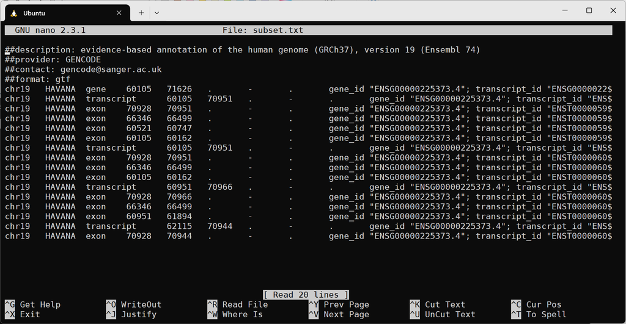

## 1.11 Generate RSA keypair

**For Windows Users**

1. Open *PuTTYgen*

[figure not shown]

2. Set parameters (RSA and 2048 bits)
3. Click **Generate**

Once key is generated

[figure not shown]

4. Set key comment
5. Enter a passphrase
6. Click **Save private key** to save the private key.
7. Click **Save public key** to save the public key.

**For macOS/Linux Users**

1. Open Terminal appliation
2. Execute the following and follow the prompts

```bash
ssh-keygen -t rsa -b 2048 -C "<netid>@uic.edu"
```

Remember: replace `<netid>` with YOUR netid. E.g., `mmaiensc@uic.edu`.

```
Generating public/private rsa key pair.
Enter file in which to save the key (/home/user/.ssh/id_rsa):
Enter passphrase (empty for no passphrase):
Enter same passphrase again:
Your identification has been saved in /home/user/.ssh/id_rsa.
Your public key has been saved in /home/user/.ssh/id_rsa.pub.
The key fingerprint is:
f1:24:99:81:eb:ec:30:a0:c6:2c:a8:24:f9:52:72:17 user@uic.edu
The key's randomart image is:
+--[ RSA 2048]----+
|       ..        |
|      .  +       |
|       .= .      |
|  . E .  =       |
|+o . +  S .      |
|B=o + o          |
|*= . +           |
|o .   .          |
| .               |
+-----------------+
```

## 1.12 Copy public key to lakeshore

**For Windows Users**

1. Open *PuTTYgen*
2. Load your private key

[figure not shown]

3. Copy public key from dialog
4. Use *PuTTY* to login to `lakeshore.acer.uic.edu`

```bash
mkdir -p .ssh
cd .ssh
nano authorized_keys
```

> - Right click in terminal window to paste key
> - Type `Ctrl + O` to save the file
> - Type `Ctrl + X` to exit

```bash
chmod -R go= ~/.ssh
```

**For MacOS/Linux Users**

1. Open Terminal App.
2. Log in to lakeshore and make sure you have a .ssh folder. Then exit lakeshore

```bash
# on lakeshore
mkdir -p .ssh
chmod -R go= ~/.ssh
exit
```

3. Execute the following on YOUR computer (not logged in to lakeshore)

```bash
# on YOUR computer
ssh-copy-id <netid>@lakeshore.acer.uic.edu
```

Remember: replace `<netid>` with YOUR netid. E.g., `mmaiensc@lakeshore.acer.uic.edu`.

## 1.13 Set up ssh key agent

This will add your private key to your agent so that all applications that use ssh can access it. This includes Putty/Terminal for logging in, as well as WinSCP/Cyberduck for SFTP. *NOTE: you’ll need to repeat these steps each time you boot up your computer.*

**For Windows Users**

1. Double-click on the private key file and enter your key’s password at the prompt.

[figure not shown]

**For MacOS/Linux Users**

1. Open Terminal App.
2. Execute the following

```bash
ssh-add -K ~/.ssh/id_rsa
```

### 1.13.1 Login to lakeshore using private key

Log in as you normally would on Putty or Terminal: you should no longer need to enter your lakeshore password or confirm your identity with Duo. Yay!

# 2 Afternoon

## 2.1 First BASH Sricpt

- Go to `workingdir` directory

```bash
cd ~/workingdir
```

- Create a new file named `printname.sh`.

```bash
nano printname.sh
```

- Edit the file to have the following contents.

```bash
#!/bin/sh
date
whoami
echo "Hello YOURNAME"
```

- Save the file (`Ctrl + O`) and quit (`Ctrl + X`) .
- Execute the script

```bash
sh printname.sh
```

```
Mon Jun 23 02:37:53 PM CDT 2025
gchlip2
Hello YOURNAME
```

## 2.2 Second BASH Sricpt

- Go to `workingdir` directory

```bash
cd ~/workingdir
```

- Create a new file named `print.sh`.

```bash
nano print.sh
```

- Edit the file to have the following contents.

```bash
#!/bin/sh
scriptName=$0
name=$1
echo "Script Name: $0"

echo "Script Name: $scriptName"

echo "Hello $1"
echo "Hello $name"
```

- Save the file (`Ctrl + O`) and quit (`Ctrl + X`)
- Execute the script with a name

```bash
sh print.sh Tom
```

```
Script Name: print.sh
Script Name: print.sh
Hello Tom
Hello Tom
```

## 2.3 Add `if` statement to BASH script

- Go to `workingdir` directory

```bash
cd ~/workingdir
```

- Open `print.sh` using `nano`.

```bash
nano print.sh
```

- Edit the file to appear as follows

```bash
#!/bin/sh
if [ "$1" == "" ] ; then
    echo "Please give me your name"
    exit
fi
scriptName=$0
name=$1
echo "Script Name: $0"
echo "Script Name: $scriptName"
echo "Hello $1"
echo "Hello $name"
```

- Save the file (`Ctrl + O`) and quit (`Ctrl + X`)
- Execute the script without a name

```bash
sh print.sh
```

```
Please give me your name
```

- Execute the script with a name

```bash
sh print.sh Tom
```

```
Script Name: print.sh
Script Name: print.sh
Hello Tom
Hello Tom
```

## 2.4 BASH script with loops

### 2.4.1 `for` loop

- Go to `workingdir` directory

```bash
cd ~/workingdir
```

- Edit a new file named `forloop.sh`

```bash
nano forloop.sh
```

- Edit the file to have the following contents

```bash
#!/bin/sh
fnamelist=/workshops/ric_workshop/common/2_LinuxHPC/files/*.fastq.gz
for file in $fnamelist
do
    echo "A file: $file"
done
```

- Save the file (`Ctrl + O`) and quit (`Ctrl + X`) .
- Execute the script

```bash
sh forloop.sh
```

```
A file: /workshops/ric_workshop/common/2_LinuxHPC/files/A_R1.fastq.gz
A file: /workshops/ric_workshop/common/2_LinuxHPC/files/A_R2.fastq.gz
A file: /workshops/ric_workshop/common/2_LinuxHPC/files/B_R1.fastq.gz
A file: /workshops/ric_workshop/common/2_LinuxHPC/files/B_R2.fastq.gz
```

### 2.4.2 `while` loop (Take home Exercise)

- Go to `workingdir` directory

```bash
cd ~/workingdir
```

- Edit a new file named `gene_names.txt`

```bash
nano gene_names.txt
```

- Edit the file to have the following contents

```bash
APOE
NOTCH3
ERCC1
```

- Save the file (`Ctrl + O`) and quit (`Ctrl + X`).
- Edit a new file named `whileloop.sh`

```bash
nano whileloop.sh
```

- Edit the file to have the following contents

```bash
#!/bin/sh
file_list=$1    # First argument: file containing list of search terms (e.g., gene names)
file_data=$2    # Second argument: file where we want to search those terms
file_out-=$3    # Third argument: file where we will save output
# Loop through each line in the list file
while read -r line; do
    echo "Searching for: $line"
    # Search for exact match of $line in the input file
    # within that search keep only lines which word gene
    # append results to output file
    grep -w $line $file_data | grep -w gene >> $file_out
  done < "$file_list"
```

- Save the file (`Ctrl + O`) and quit (`Ctrl + X`).
- Execute the script

```bash
sh whileloop.sh gene_names.txt hg19_chr19.gtf subset_chr19.gtf
```

- using `more`, `less` or `cat` command check the output of the subset_chr19.gtf

```bash
less subset_chr19.gtf
```

```
chr19   HAVANA  gene    45409011    45412650    .   +   .   gene_id "ENSG00000130203.5"; transcript_id "ENSG00000130203.5"; gene_type "protein_coding"; gene_status "KNOWN"; gene_name "APOE"; transcript_type "protein_coding"; transcript_status "KNOWN"; transcript_name "APOE"; level 2; havana_gene "OT…
chr19   HAVANA  transcript  45409011    45412650    .   +   .   gene_id "ENSG00000130203.5"; transcript_id "ENST00000252486.4"; gene_type "protein_coding"; gene_status "KNOWN"; gene_name "APOE"; transcript_type "protein_coding"; transcript_status "KNOWN"; transcript_name "APOE-001"; level 2; tag "ba…
[...]
chr19   HAVANA  UTR 45926633    45926639    .   -   .   gene_id "ENSG00000012061.11"; transcript_id "ENST00000589214.1"; gene_type "protein_coding"; gene_status "KNOWN"; gene_name "ERCC1"; transcript_type "protein_coding"; transcript_status "KNOWN"; transcript_name "ERCC1-005"; level 2; tag "alterna…
```

## 2.5 Concept of PATH and Load Modules (Demo Exercise)

- Go to `workingdir` directory

```bash
# 1. Try running STAR before loading the module
STAR

# 2. Check if STAR is available in your current PATH
which STAR

# 3. Check currently loaded modules
module list

# 4. Load the STAR module
module load STAR
# 5. Confirm STAR is now in your PATH
which STAR

# 6. Confirm STAR is now loaded
module list

# 7. Run STAR help to test if it works
STAR --help

# 8. Purge all loaded modules
module purge

# 9. Check again to see that STAR is no longer available
which STAR
```

## 2.6 Write and submit a SLURM job

- Change to home directory and edit a new file named `myjob.sh`

```bash
cd ~
cp /workshops/ric_workshop/common/2_LinuxHPC/SLURM_template.sh myjob.sh
nano myjob.sh
```

- Edit the file to have the following contents

```bash
#!/bin/bash
#SBATCH --job-name=myjob             # Optional: name of the job
#SBATCH --output=slurm-%j.out        # Merge stdout/stderr to this file (%j = job ID)
#SBATCH --mail-type=BEGIN,END,FAIL   # Notifications for job begin, end, or fail
#SBATCH --mail-user=yourname@uic.edu # Email address for notifications
#SBATCH --time=10:00:00              # Walltime: 10 hours
#SBATCH --mem=20G                    # Total memory for the job
#SBATCH --nodes=1                    # Number of nodes
#SBATCH --ntasks-per-node=12         # Number of cores (tasks) on each node
#SBATCH --partition=batch            # Partition/queue (often 'batch' or 'standard')
#SBATCH --account=ric_workshop

# Move to working directory
cd ~/workingdir
INPUT="hg19_chr19.gtf"
OUTPUT="test.txt"

echo  “Running command"
grep APOE $INPUT | cut –f3 | sort | uniq -c > $OUTPUT
```

- Save the file and quit.
- Submit the job using `sbatch`

```bash
sbatch myjob.sh
```

```
Submitted batch job 103909
```

```bash
cat myjob.sh.o<some number>
```

[output not shown]

## 2.7 Transfer files to/from lakeshore

1. Open *WinSCP*/*Cyberduck*
2. Connect to `lakeshore.acer.uic.edu`

[figure not shown]

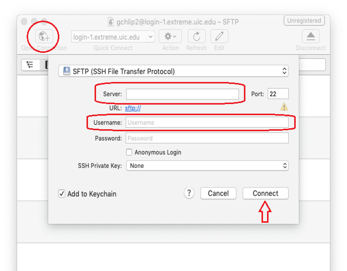

3. Click on `workingdir` to open the directory
4. Copy the file `test.txt` to your desktop
5. Return to your home directory

## 2.8 check file integrity: `md5sum`

- Go to `workingdir` directory

```bash
cd ~/workingdir
```

- run `md5sum` command on test.txt

```bash
md5sum test.txt
```

- STDOUT

```
98d277ebc3863ceb3fc90f61e25321d9  test.txt
```

- Edit test.txt. Added extra word or two and rerun `md5sum`

```bash
nano test.txt
## add couple of words/characters to test.txt
## re-run md5sum command.
## Is fingerprint of the file same as the earlier?
md5sum test.txt
```

## 2.9 sed

- Go to `workingdir` directory

```bash
cd ~/workingdir
```

- Using sed with GTF Files: Extract, Modify, and Save Output
  - Get top 10 lines from `hg19_chr19.gtf`.
  - Using `sed` replace ‘chr19’ with ‘CHR19’
  - save output to the file

```bash
head –n 10 hg19_chr19.gtf |  sed 's/chr19/CHR19/’ > chr19_mod.gtf
```

- view output of `chr19_mod.gtf` using `cat`, `less` or `more`

```bash
more chr19_mod.gtf
```

```
##description: evidence-based annotation of the human genome (GRCh37), version 19 (Ensembl 74)
##provider: GENCODE
##contact: gencode@sanger.ac.uk
##format: gtf
CHR19   HAVANA  gene    60105   71626   .   -   .   gene_id "ENSG00000225373.4"; transcript_id "ENSG00000225373.4"; gene_type "pseudogene"; gene_status "KNOWN"; gene_n
ame "WASH5P"; transcript_type "pseudogene"; transcript_status "KNOWN"; transcript_name "WASH5P"; level 2; havana_gene "OTTHUMG00000180466.5";
[...]
CHR19   HAVANA  exon    60105   60162   .   -   .   gene_id "ENSG00000225373.4"; transcript_id "ENST00000592209.2"; gene_type "pseudogene"; gene_status "KNOWN"; gene_n
ame "WASH5P"; transcript_type "processed_transcript"; transcript_status "KNOWN"; transcript_name "WASH5P-002"; exon_number 4;  exon_id "ENSE00002846866.1";  level 2; havana_gene "
OTTHUMG00000180466.5"; havana_transcript "OTTHUMT00000453532.2";
```

## 2.10 awk

- Go to `workingdir` directory

```bash
cd ~/workingdir
```

- Extract Specific Features from a GTF File Using awk
  - check what features are present in the GTF file .
  - Hint: `cut –f 3 chr19_hg19.gtf | sort | uniq –c`
  - print only lines with a given feature
  - pipe it to `head` to check top 10 lines.

```bash
awk -F'\t' 'BEGIN { OFS="\t" } { if ($3 == "gene") print $0 }’ chr19_hg19.gtf | head
```

```
chr19   HAVANA  gene    60105   71626   .   -   .   gene_id "ENSG00000225373.4"; transcript_id "ENSG00000225373.4"; gene_type "pseudogene"; gene_status "KNOWN"; gene_name "WASH5P"; transcript_type "pseudogene"; transcript_status "KNOWN"; transcript_name "WASH5P"; level 2; havana_gene "OTTHUMG0000018…
[...]
chr19   HAVANA  gene    176907  177913  .   +   .   gene_id "ENSG00000267290.1"; transcript_id "ENSG00000267290.1"; gene_type "lincRNA"; gene_status "NOVEL"; gene_name "AC092192.1"; transcript_type "lincRNA"; transcript_status "NOVEL"; transcript_name "AC092192.1"; level 2; havana_gene "OTTHUMG00000…
```

- Extract few selected columns for a given feature

```bash
awk -F'\t' 'BEGIN { OFS="\t" } { if ($3 == "gene") print $1, $3, $4, $5 }' \
chr19_hg19.gtf | head
```

```
chr19   gene    60105   71626
chr19   gene    71161   72719
chr19   gene    76220   77690
chr19   gene    94062   96511
chr19   gene    104535  105471
chr19   gene    107471  111696
chr19   gene    145485  145812
chr19   gene    156279  157215
chr19   gene    159361  174665
chr19   gene    176907  177913
```

# 3 Extra Take-home Excersis

## 3.1 Compress and decompress file/directory

Compress the file using different utilities

### 3.1.1 Using `gzip`

- Go to `workingdir` directory

```bash
cd ~/workingdir
```

- Compress gtf file using `gzip` utility; check file size before and after.

```bash
ls -lh hg19_chr19.gtf
```

```
-rw-r--r-- 1 gchlip2 gchlip2 68M Jun 23 14:37 hg19_chr19.gtf
```

```bash
gzip hg19_chr19.gtf
ls -lh hg19_chr19.gtf.gz
```

```
-rw-r--r-- 1 gchlip2 gchlip2 2.4M Jun 23 14:37 hg19_chr19.gtf.gz
```

- Use `gunzip` in stream fashion and `head` the contents.

```bash
gunzip -c hg19_chr19.gtf.gz | head
```

```
##description: evidence-based annotation of the human genome (GRCh37), version 19 (Ensembl 74)
##provider: GENCODE
##contact: gencode@sanger.ac.uk
##format: gtf
chr19   HAVANA  gene    60105   71626   .   -   .   gene_id "ENSG00000225373.4"; transcript_id "ENSG00000225373.4"; gene_type "pseudogene"; gene_status "KNOWN"; gene_name "WASH5P"; transcript_type "pseudogene"; transcript_status "KNOWN"; transcript_name "WASH5P"; level 2; havana_gene "OTTHUMG0000018…
chr19   HAVANA  transcript  60105   70951   .   -   .   gene_id "ENSG00000225373.4"; transcript_id "ENST00000592209.2"; gene_type "pseudogene"; gene_status "KNOWN"; gene_name "WASH5P"; transcript_type "processed_transcript"; transcript_status "KNOWN"; transcript_name "WASH5P-002"; level 2; havana_ge…
chr19   HAVANA  exon    70928   70951   .   -   .   gene_id "ENSG00000225373.4"; transcript_id "ENST00000592209.2"; gene_type "pseudogene"; gene_status "KNOWN"; gene_name "WASH5P"; transcript_type "processed_transcript"; transcript_status "KNOWN"; transcript_name "WASH5P-002"; exon_number 1;  exon_i…
chr19   HAVANA  exon    66346   66499   .   -   .   gene_id "ENSG00000225373.4"; transcript_id "ENST00000592209.2"; gene_type "pseudogene"; gene_status "KNOWN"; gene_name "WASH5P"; transcript_type "processed_transcript"; transcript_status "KNOWN"; transcript_name "WASH5P-002"; exon_number 2;  exon_i…
chr19   HAVANA  exon    60521   60747   .   -   .   gene_id "ENSG00000225373.4"; transcript_id "ENST00000592209.2"; gene_type "pseudogene"; gene_status "KNOWN"; gene_name "WASH5P"; transcript_type "processed_transcript"; transcript_status "KNOWN"; transcript_name "WASH5P-002"; exon_number 3;  exon_i…
chr19   HAVANA  exon    60105   60162   .   -   .   gene_id "ENSG00000225373.4"; transcript_id "ENST00000592209.2"; gene_type "pseudogene"; gene_status "KNOWN"; gene_name "WASH5P"; transcript_type "processed_transcript"; transcript_status "KNOWN"; transcript_name "WASH5P-002"; exon_number 4;  exon_i…
```

### 3.1.2 Using `tar`

- Create a **t**ape **ar**chive (`tar`) of your `workingdir`

```bash
cd ~
tar -czf wd.tar.gz workingdir
mv wd.tar.gz workingdir
cd workingdir
tar -tf wd.tar.gz
```

```
workingdir/
workingdir/myfirstsubdir/
workingdir/filename.txt
workingdir/myfirstfile.txt
workingdir/hg19_chr19.gtf.gz
workingdir/t1.txt
workingdir/output.txt
```

```bash
tar -zxf wd.tar.gz
ls
```

```
filename.txt
hg19_chr19.gtf.gz
myfirstfile.txt
myfirstsubdir
output.txt
t1.txt
wd.tar.gz
workingdir
```

`tar` options

- `-c` Create a new archive
- `-z` Compress the archive with gzip
- `-x` Extract
- `-f` file
- `-t` List archive contents to stdout

## 3.2 Bioinformatics Shell Workflow: Download and Analyze

- Objective
  - Download a processed gene expression file from GEO
  - Decompress the file
  - Explore the contents using `awk`
- Download normalized count matrix from GEO series **GSE160351**.

```bash
# make new directory
mkdir GSE160351
cd GSE160351
# Download the count matrix (compressed)
wget https://ftp.ncbi.nlm.nih.gov/geo/series/GSE160nnn/GSE160351/suppl/GSE160351_DESEQ2_normalized_counts.txt.gz
```

- check if GSE160351_DESEQ2_normalized_counts.txt.gz got downloaded

```bash
ls
```

```
GSE160351_DESEQ2_normalized_counts.txt.gz
```

- Use `gunzip` in stream fashion and `head` the contents.

```bash
gunzip -c GSE160351_DESEQ2_normalized_counts.txt.gz | head
```

[output not shown]

```bash
gzip GSE160351_DESEQ2_normalized_counts.txt.gz
```

### 3.2.1 use awk to print the first column of the file: Ensemble ids

```bash
awk 'NR > 1 { print $1 }' GSE160351_DESEQ2_normalized_counts.txt
```

```
ENSG00000223972
ENSG00000227232
ENSG00000278267
ENSG00000243485
ENSG00000237613
ENSG00000186092
ENSG00000238009
ENSG00000233750
ENSG00000268903
ENSG00000269981
```

### 3.2.2 Print gene IDs where any expression value > 7.5

- Loop through all expression columns. If any sample has a value > 7.5,  
  print the gene ID. Observation
  - NR > 1 skip the header row
  - i=2 correctly skips the Ensemble ID (1st column) and checks only sample columns
  - NF = number of fields (Ensemble ID column + all sample columns)
  - break stops after first match

```bash
awk 'NR > 1 { \
  for(i=2;i<=NF;i++) \
    if($i > 7.5) { print $1; break } \
}' GSE160351_DESEQ2_normalized_counts.txt
```

```
ENSG00000227232
ENSG00000268903
ENSG00000269981
ENSG00000241860
ENSG00000279457
ENSG00000237094
ENSG00000225630
ENSG00000237973
ENSG00000248527
ENSG00000198744
```

### 3.2.3 Replace Sample Prefixes in Header (Lib_ → Sample_)

- Observation:
  - 1: Only apply to line 1 (the header row).
  - s: Substitute (search and replace).
  - Lib_: The pattern to find (sample names start with this).
  - Sample_: The replacement text.
  - g: Global, meaning replace all occurrences on that line (not just the first one).

```
sed '1s/Lib_/Sample_/g' GSE160351_DESEQ2_normalized_counts.txt
```